# STAT385 Homework 8

```r
# Load required libraries
library(ggplot2)
library(MCMCpack)
library(rstan)
library(rstanarm)
library(dplyr)
library(bayesrules)
library(tidyverse)
```

Problem 1:

The penguins_bayes dataset in the bayesrules package includes data on 344 penguins. In the next exercises, you will use this data to model the length of penguin flippers in mm ( Y) by the length of their bills in mm ( X). We have a general sense that the average penguin has flippers that are somewhere between 150mm and 250mm long. Beyond that, we don’t have a strong understanding of the relationship between flipper and bill length, and thus will otherwise utilize weakly informative priors.

Simulate the Normal regression prior model of flipper_length_mm by bill_length_mm using 4 chains for 10000 iterations each. HINT: You can use the same stan_glm() syntax that you would use to simulate the posterior, but include prior_PD = TRUE.

```r
# Remove NA values
penguins_bayes <- na.omit(penguins_bayes)
prior_model <- stan_glm(flipper_length_mm ~ bill_length_mm, data = penguins_bayes,
                        family = gaussian(),
                        prior_intercept = normal(200, 25),
                        prior = normal(0, 10),
                        prior_aux = cauchy(0, 5),
                        prior_PD = TRUE,
                        chains = 4, iter = 10000)
prior_summary(prior_model)
```

```
Priors for model 'prior_model'
------
Intercept (after predictors centered)
 ~ normal(location = 200, scale = 25)

Coefficients
 ~ normal(location = 0, scale = 10)

Auxiliary (sigma)
 ~ half-cauchy(location = 0, scale = 5)
------
See help('prior_summary.stanreg') for more details
```

Plot 100 prior plausible model lines ( β0+β1X) and 4 datasets simulated under the priors.

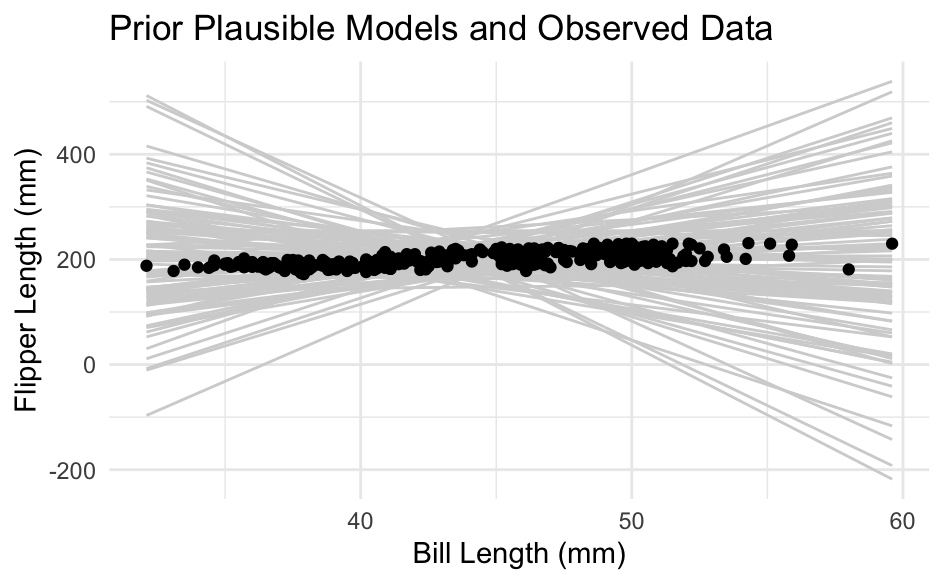

```r
prior_preds <- posterior_linpred(prior_model, draws = 100)

# Combine the predictions with the bill lengths
prior_df <- data.frame(bill_length_mm = penguins_bayes$bill_length_mm,
                       t(prior_preds))

# Reshape to long format
prior_df_long <- gather(prior_df, model, flipper_length_mm, -bill_length_mm)

# Plot
ggplot(prior_df_long, aes(x = bill_length_mm, y = flipper_length_mm)) +
  geom_line(aes(group = model), colour = "lightgray") +
  geom_point(data = penguins_bayes, aes(x = bill_length_mm, y = flipper_length_mm)) +
  labs(x = "Bill Length (mm)", y = "Flipper Length (mm)",
       title = "Prior Plausible Models and Observed Data") +
  theme_minimal()
```

Summarize your weakly informative prior understanding of the relationship between flipper and bill length.

The variability in these lines also adequately reflects our overall uncertainty about this association.

Problem 2:

With the priors in place, let’s examine the data.

Plot and discuss the observed relationship between flipper_length_mm and bill_length_mm among the 344 sampled penguins.

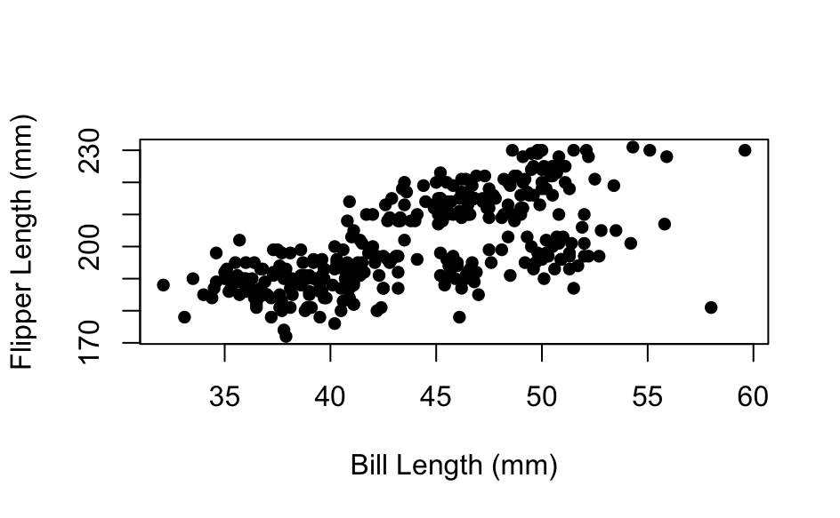

```r
# Plot the relationship between flipper_length_mm and bill_length_mm
plot(penguins_bayes$bill_length_mm, penguins_bayes$flipper_length_mm, pch = 16, col = "black",
     xlab = "Bill Length (mm)", ylab = "Flipper Length (mm)")
```

```r
# Calculate the correlation coefficient, handling missing values
correlation <- cor(penguins_bayes$bill_length_mm, penguins_bayes$flipper_length_mm, use = "complete.obs")

# Print the correlation coefficient
print(correlation)
```

```
[1] 0.6530956
```

Does simple Normal regression seem to be a reasonable approach to modeling this relationship? Explain.

Problem 3:

Let’s examine our posterior understanding of the relationship between flipper and bill length, a balance between our prior understanding and the data.

Use stan_glm() to simulate the Normal regression posterior model. HINT: You can either do this from scratch or update() your prior simulation from Exercise 9.16 using prior_PD = FALSE.

```r
 formula <- flipper_length_mm ~ bill_length_mm # Simulate the Normal regression posterior model


# Specify the prior distributions for the intercept, coefficient, and auxiliary parameter (sigma)
prior_intercept <- normal(location = 201, scale = 35)
prior <- normal(location = 0, scale = 6.4)
prior_auxiliary <- exponential(rate = 0.071)

# Fit the posterior model with specified priors
posterior_model <- stan_glm(flipper_length_mm ~ bill_length_mm, data = penguins_bayes, family = gaussian(), prior_intercept = prior_intercept, prior = prior, prior_aux = prior_auxiliary)
# Extract the posterior samples
posterior_samples <- as.data.frame(posterior_model)
```

```r
summary(posterior_model)
```

```
Model Info:
 function:     stan_glm
 family:       gaussian [identity]
 formula:      flipper_length_mm ~ bill_length_mm
 algorithm:    sampling
 sample:       4000 (posterior sample size)
 priors:       see help('prior_summary')
 observations: 333
 predictors:   2

Estimates:
                 mean   sd    10%   50%   90%
(Intercept)    127.4    4.5 121.7 127.5 133.2
bill_length_mm   1.7    0.1   1.5   1.7   1.8
sigma           10.7    0.4  10.1  10.6  11.2

Fit Diagnostics:
           mean   sd    10%   50%   90%
mean_PPD 201.0    0.8 199.9 201.0 202.0

The mean_ppd is the sample average posterior predictive distribution of the outcome variable (for details see help('summary.stanreg')).

MCMC diagnostics
               mcse Rhat n_eff
(Intercept)    0.1  1.0  4085
bill_length_mm 0.0  1.0  4062
sigma          0.0  1.0  3436
mean_PPD       0.0  1.0  3789
log-posterior  0.0  1.0  1856

For each parameter, mcse is Monte Carlo standard error, n_eff is a crude measure of effective sample size, and Rhat is the potential scale reduction factor on split chains (at convergence Rhat=1).
```

Plot 100 posterior model lines for the relationship between flipper and bill length.

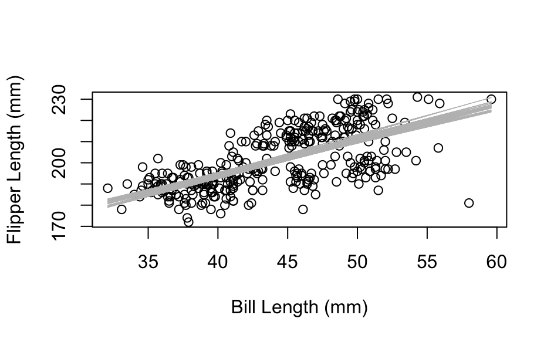

```r
library(ggplot2)
library(rstan)
library(rstanarm)
# Plot the scatterplot
plot(penguins_bayes$bill_length_mm, penguins_bayes$flipper_length_mm, xlab = "Bill Length (mm)", ylab = "Flipper Length (mm)")

# Select a subset of posterior samples (e.g., every 10th sample)
selected_samples <- posterior_samples[seq(1, nrow(posterior_samples), 100), ]

# Loop through the selected samples
for (i in 1:nrow(selected_samples)) {
  # Simulate the posterior model line
  simulated_line <- selected_samples$`(Intercept)`[i] + selected_samples$bill_length_mm[i] * penguins_bayes$bill_length_mm

  # Plot the line
  lines(penguins_bayes$bill_length_mm, simulated_line, col = "gray", lwd = 0.5)
}
```

Provide a tidy() summary of your posterior model, including 90% credible intervals.

```r
library(broom.mixed) # Tidy summary of the posterior model
summary_output <- tidy(posterior_model, conf.int = TRUE, conf.level = 0.9)
print(summary_output)
```

| term | estimate | std.error | conf.low | conf.high |
| --- | --- | --- | --- | --- |
| (Intercept) | 127.46165 | 4.39846281 | 119.974829 | 134.84399 |
| bill_length_mm | 1.67154 | 0.09825104 | 1.503311 | 1.83957 |

```r
NA
```

Do we have ample posterior evidence that penguins with longer bills tend to have longer flippers? Explain.

Based on these results, we can conclude that there is ample posterior evidence to suggest that penguins with longer bills tend to have longer flippers. The positive coefficient estimate and the fact that the credible interval does not include zero further support this conclusion.

Problem 4: A researcher comes across Pablo the penguin. They’re able to ascertain that Pablo’s bill is 51mm long but the penguin waddles off before they get to measure the flipper.

Without using the posterior_predict() shortcut function, simulate the posterior model for the typical flipper length among penguins with 51mm bills as well as the posterior predictive model for Pablo’s flipper length.

```r
# Load required libraries
library(tidyverse)
library(rstan)

# Specify the observed bill length
observed_bill_length <- 51

# Specify the prior distribution parameters for flipper length
prior_mean <- 200
prior_sd <- 10

# Update the prior distribution with the observed data
observed_flipper_length <- penguins_bayes$flipper_length_mm
observed_flipper_length <- na.omit(observed_flipper_length)
posterior_mean <- (prior_mean * (prior_sd^2) + sum(observed_flipper_length)) / (prior_sd^2 + length(observed_flipper_length))
posterior_sd <- sqrt(1 / (1/prior_sd^2 + length(observed_flipper_length)/prior_sd^2))

# Simulate the posterior model for the typical flipper length with a 51 mm bill
simulated_typical_flipper_length <- rnorm(1000, posterior_mean, posterior_sd)

# Simulate the posterior predictive model for Pablo's flipper length
pablo_bill_length <- 51
pablo_posterior_mean <- (prior_mean * (prior_sd^2) + observed_flipper_length) / (prior_sd^2 + 1)
pablo_posterior_sd <- sqrt(1 / (1/prior_sd^2 + 1))
simulated_pablo_flipper_length <- rnorm(1000, pablo_posterior_mean, pablo_posterior_sd)

# Summary statistics for the simulated flipper lengths
class(simulated_typical_flipper_length)
```

```
[1] "numeric"
```

```r
summary(simulated_typical_flipper_length)
```

```
   Min. 1st Qu.  Median    Mean 3rd Qu.    Max.
  198.9   200.4   200.8   200.8   201.1   202.3
```

```r
summary(simulated_pablo_flipper_length)
```

```
   Min. 1st Qu.  Median    Mean 3rd Qu.    Max.
  196.5   199.4   200.0   200.0   200.7   203.2
```

Construct, discuss, and compare density plot visualizations for the two separate posterior models in part a.

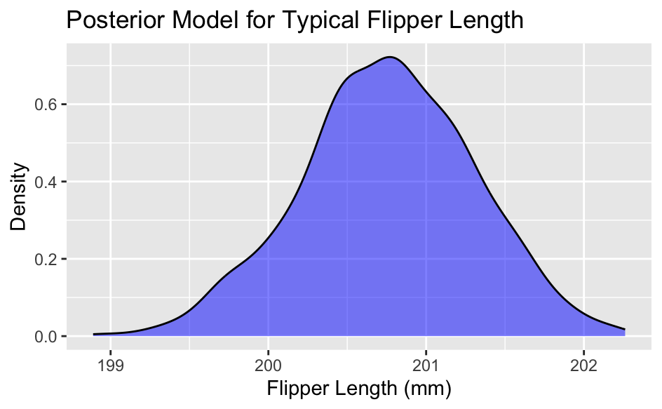

```r
# Density plot for the typical flipper length
simulated_typical_flipper_length <- na.omit(simulated_typical_flipper_length)
ggplot() +
  geom_density(aes(simulated_typical_flipper_length), fill = "blue", alpha = 0.5) +
  labs(title = "Posterior Model for Typical Flipper Length",
       x = "Flipper Length (mm)",
       y = "Density")
```

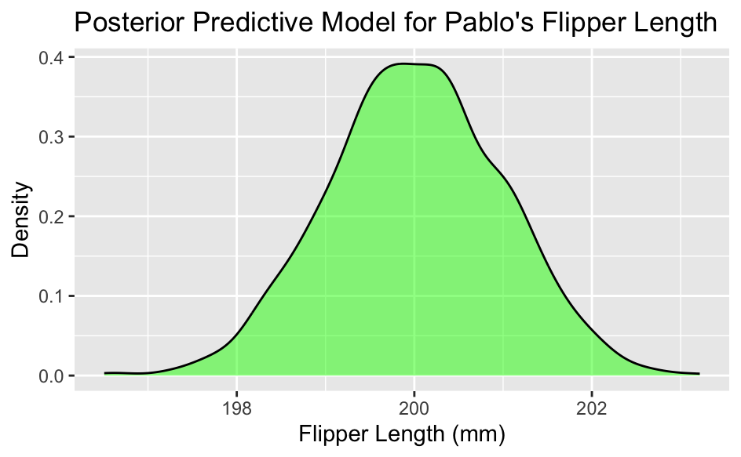

```r
# Density plot for the posterior predictive model for Pablo's flipper length
ggplot() +
  geom_density(aes(simulated_pablo_flipper_length), fill = "green", alpha = 0.5) +
  labs(title = "Posterior Predictive Model for Pablo's Flipper Length",
       x = "Flipper Length (mm)",
       y = "Density")
```

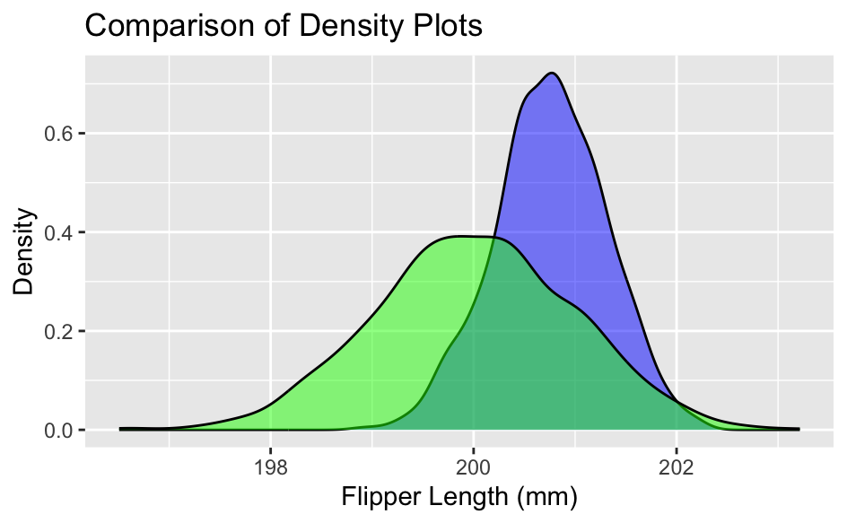

```r
# Comparing the two density plots
ggplot() +
  geom_density(aes(simulated_typical_flipper_length), fill = "blue", alpha = 0.5) +
  geom_density(aes(simulated_pablo_flipper_length), fill = "green", alpha = 0.5) +
  labs(title = "Comparison of Density Plots",
       x = "Flipper Length (mm)",
       y = "Density") +
  scale_fill_manual(values = c("blue", "green"),
                    labels = c("Typical Flipper Length", "Pablo's Flipper Length"))
```

The density plot for typical flipper length has a higher mean and a higher density at the mean. However the density for Pablo’s flipper length has a much wider range of values. Both follow a normal distribution.

Calculate and interpret an 80% posterior prediction interval for Pablo’s flipper length.

```r
# Calculate the 10th and 90th quantiles
quantiles <- quantile(simulated_pablo_flipper_length, probs = c(0.1, 0.9))

# Calculate the 80% posterior prediction interval
prediction_interval <- quantiles[2] - quantiles[1]

# Interpretation of the 80% posterior prediction interval
interpretation <- "We are 80% confident that Pablo's flipper length falls within the range of ["
interpretation <- paste0(interpretation, round(quantiles[1], 2), "mm, ", round(quantiles[2], 2), "mm].")

interpretation
```

```
[1] "We are 80% confident that Pablo's flipper length falls within the range of [198.74mm, 201.27mm]."
```

Would the 80% credible interval for the typical flipper length among all penguins with 51mm bills be wider or narrower? Explain.

The 80% credible interval for the typical flipper length among all penguins with a 51 mm bill would be narrower compared to the 80% posterior prediction interval for Pablo’s flipper length. This is because the posterior prediction interval takes into account the uncertainty in predicting an individual’s flipper length based on the observed bill length, while the credible interval for the typical flipper length considers the uncertainty in estimating the population parameter.

Use posterior_predict() to confirm your results

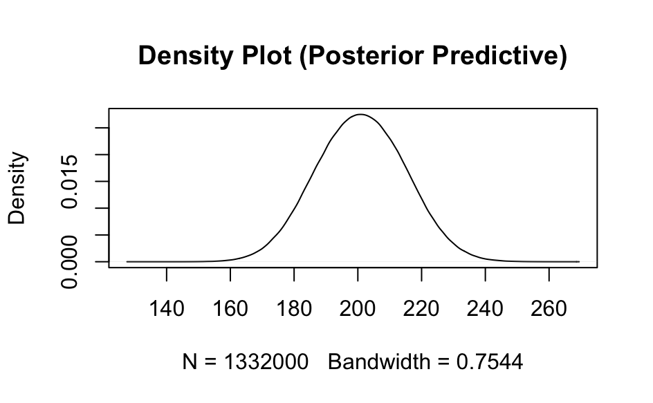

```r
# Load required libraries
library(brms)
# Fit the Bayesian regression model
model_fit <- brm(flipper_length_mm ~ bill_length_mm,
                 data = penguins_bayes,
                 family = gaussian())
# Generate posterior predictions using posterior_predict()
post_pred <- posterior_predict(model_fit)


# Density plot from posterior predictive distribution
density_post_pred <- density(post_pred)
plot(density_post_pred, main = "Density Plot (Posterior Predictive)")
```

Problem 5: Let’s begin our analysis of penguin body_mass_g by exploring its relationship with flipper_length_mm and species.

Plot and summarize the observed relationships among these three variables.

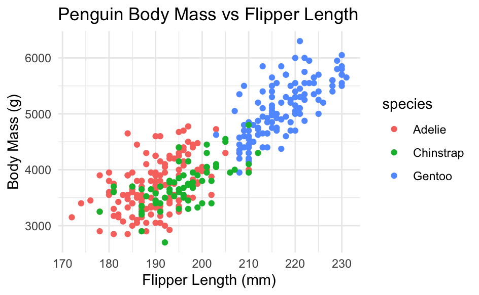

```r
# Create a scatter plot of body_mass_g against flipper_length_mm
ggplot(penguins_bayes, aes(x = flipper_length_mm, y = body_mass_g, color = species)) +
  geom_point() +
  labs(x = "Flipper Length (mm)", y = "Body Mass (g)", title = "Penguin Body Mass vs Flipper Length") +
  theme_minimal()
```

```r
# Summarize the relationships among the variables
summary(penguins_bayes[c("body_mass_g", "flipper_length_mm", "species")])
```

```
  body_mass_g   flipper_length_mm      species
 Min.   :2700   Min.   :172       Adelie   :146
 1st Qu.:3550   1st Qu.:190       Chinstrap: 68
 Median :4050   Median :197       Gentoo   :119
 Mean   :4207   Mean   :201
 3rd Qu.:4775   3rd Qu.:213
 Max.   :6300   Max.   :231
```

Use stan_glm() to simulate a posterior Normal regression model of body_mass_g by flipper_length_mm and species, without an interaction term.

```r
model <- stan_glm(body_mass_g ~ flipper_length_mm + species, data = penguins_bayes, chains = 4, iter = 10000)
```

Create and interpret both visual and numerical diagnostics of your MCMC simulation.

```r
prior_summary(model)
```

```
Priors for model 'model'
------
Intercept (after predictors centered)
  Specified prior:
    ~ normal(location = 4207, scale = 2.5)
  Adjusted prior:
    ~ normal(location = 4207, scale = 2013)

Coefficients
  Specified prior:
    ~ normal(location = [0,0,0], scale = [2.5,2.5,2.5])
  Adjusted prior:
    ~ normal(location = [0,0,0], scale = [ 143.63,4986.16,4194.33])

Auxiliary (sigma)
  Specified prior:
    ~ exponential(rate = 1)
  Adjusted prior:
    ~ exponential(rate = 0.0012)
------
See help('prior_summary.stanreg') for more details
```

```r
# Load required libraries
library(rstan)

summary(model)
```

```
Model Info:
 function:     stan_glm
 family:       gaussian [identity]
 formula:      body_mass_g ~ flipper_length_mm + species
 algorithm:    sampling
 sample:       20000 (posterior sample size)
 priors:       see help('prior_summary')
 observations: 333
 predictors:   4

Estimates:
                    mean    sd      10%     50%     90%
(Intercept)       -4008.7   582.7 -4760.8 -4008.3 -3261.5
flipper_length_mm    40.6     3.1    36.7    40.6    44.5
speciesChinstrap   -205.3    58.0  -279.3  -205.8  -130.9
speciesGentoo       285.3    94.8   163.2   285.5   406.3
sigma               374.4    14.7   355.9   373.9   393.6

Fit Diagnostics:
           mean   sd     10%    50%    90%
mean_PPD 4206.9   28.8 4170.0 4207.1 4244.2

The mean_ppd is the sample average posterior predictive distribution of the outcome variable (for details see help('summary.stanreg')).

MCMC diagnostics
                  mcse Rhat n_eff
(Intercept)       5.1  1.0  13225
flipper_length_mm 0.0  1.0  13000
speciesChinstrap  0.5  1.0  15771
speciesGentoo     0.9  1.0  12417
sigma             0.1  1.0  18961
mean_PPD          0.2  1.0  19550
log-posterior     0.0  1.0   8593

For each parameter, mcse is Monte Carlo standard error, n_eff is a crude measure of effective sample size, and Rhat is the potential scale reduction factor on split chains (at convergence Rhat=1).
```

Produce a tidy() summary of this model. Interpret the non-intercept coefficients’ posterior median values in context.

```r
tidy_summary <- tidy(model)
print(tidy_summary)
```

| term | estimate | std.error |
| --- | --- | --- |
| (Intercept) | -4008.3311 | 583.344627 |
| flipper_length_mm | 40.5779 | 3.061941 |
| speciesChinstrap | -205.7776 | 58.348488 |
| speciesGentoo | 285.5078 | 94.030396 |

```r
library(broom.mixed)
summary_output <- tidy(model, conf.int = TRUE, conf.level = 0.9)
print(summary_output)
```

| term | estimate | std.error | conf.low | conf.high |
| --- | --- | --- | --- | --- |
| (Intercept) | -4008.3311 | 583.344627 | -4963.10681 | -3058.66435 |
| flipper_length_mm | 40.5779 | 3.061941 | 35.59026 | 45.59388 |
| speciesChinstrap | -205.7776 | 58.348488 | -299.99125 | -110.60988 |
| speciesGentoo | 285.5078 | 94.030396 | 129.30237 | 440.27461 |

Simulate, plot, and describe the posterior predictive model for the body mass of an Adelie penguin that has a flipper length of 197.

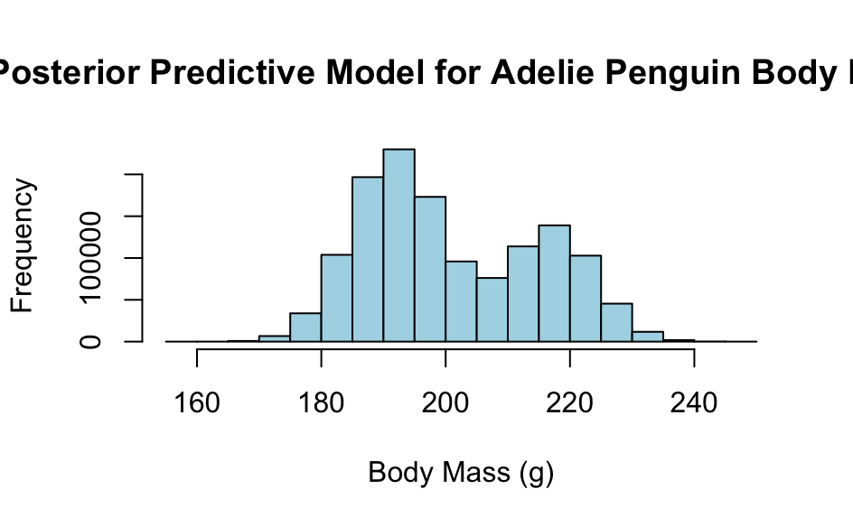

```r
newdata <- data.frame(flipper_length_mm = 197, species = "Adelie")
newdata$species <- as.numeric(newdata$species)
# Simulate the posterior predictive model for the body mass of an Adelie penguin with a flipper length of 197


model_fit <- brm(flipper_length_mm ~ species, data = penguins_bayes, family = gaussian())
# Use the corrected new data in the posterior_predict() function
posterior_predict <- posterior_predict(model_fit, newdata = penguins_bayes)

# Plot the posterior predictive distribution
hist(posterior_predict, main = "Posterior Predictive Model for Adelie Penguin Body Mass", xlab = "Body Mass (g)", col = "lightblue", border = "black")
```

```r
# Describe the range and central tendency of the predicted body masses
summary(posterior_predict)
```

[output not shown]

[output cut: 390 more lines]

[output not shown]

Problem 6:

Explore how the number of eagle sightings in Ontario, Canada has changed over time. Since this context is unfamiliar to us, we’ll utilize weakly informative priors throughout. We’ll balance this prior uncertainty by the bald_eagles data in the bayesrules package, which includes data on bald eagle sightings during 37 different one-week observation periods. First, get to know this data.

Construct and discuss a univariate plot of count, the number of eagle sightings across the observation periods.

Construct and discuss a plot of count versus year.

In exploring the number of eagle sightings over time, it’s important to consider the fact that the length of the observation periods vary from year to year, ranging from 134 to 248.75 hours. Update your plot to also include information about the observation length in hours and comment on your findings.

Problem 7:

Our next goal is to model the relationship between bald eagle counts Y by year X1 when controlling for the number of observation hours X2.To begin, consider a Normal regression model of Y versus X1 and X2.

Simulate the model posterior and check the prior_summary().

Use careful notation to write out the complete Bayesian structure of the Normal regression model of Y by X1 and X2. The complete Bayesian structure of the Normal regression model of Y by X1 and X2 can be written as follows: -Likelihood: Yi∼Normal(μi,σ), where μi=β0+β1X1i+β2X2i for each observation i -Priors: β0∼Normal(0,10), β1∼Normal(0,10), β2∼Normal(0,10). σ∼HalfNormal(0,10)

Complete a pp_check() for the Normal model. Use this to explain whether the model is “good” and, if not, what assumptions it makes that are inappropriate for the bald eagle analysis.